# HW12: Plotting with ggplot2

May 09, 2024

Chika Ikpechukwu

#### Preliminaries

Open relevant libraries

```r
library(tidyverse)
library(patchwork)
library(ggthemes)
```

### Background

The ‘USArrests’ data set in R was used for this assignment. The data set contains arrests data per 100,000 residents for assault, murder, and rape in each of the 50 US states in 1973 along with the percent of residents living in the urban areas.

```r
df1 <- USArrests
head(df1)
```

```
##            Murder Assault UrbanPop Rape
## Alabama      13.2     236       58 21.2
## Alaska       10.0     263       48 44.5
## Arizona       8.1     294       80 31.0
## Arkansas      8.8     190       50 19.5
## California    9.0     276       91 40.6
## Colorado      7.9     204       78 38.7
```

#### Data Wrangling

The following modifications were made to the dataset for better handling: 1. The rownames (which were the states) was made into a new variable ‘State’ 2. The dataset was transformed from wide to long format

*See below for the code chunk:*

```r
df1$State <- rownames(df1)
dVT <- df1 %>%
              gather(key = "Crime",
              value = "Value",
              Murder, Assault, Rape)

head(dVT)
```

```
##   UrbanPop      State  Crime Value
## 1       58    Alabama Murder  13.2
## 2       48     Alaska Murder  10.0
## 3       80    Arizona Murder   8.1
## 4       50   Arkansas Murder   8.8
## 5       91 California Murder   9.0
## 6       78   Colorado Murder   7.9
```

### Data Analysis

**Question 1: What is the crime distributions in the most populated states**

To determine this the most urbanly-populated states was first determined. Then the Crime types was plotted on a piechart by customizing the ggplot statement to include a customized ‘coord_polar()’ function (see figure 1).

*See below for the code chunk:*

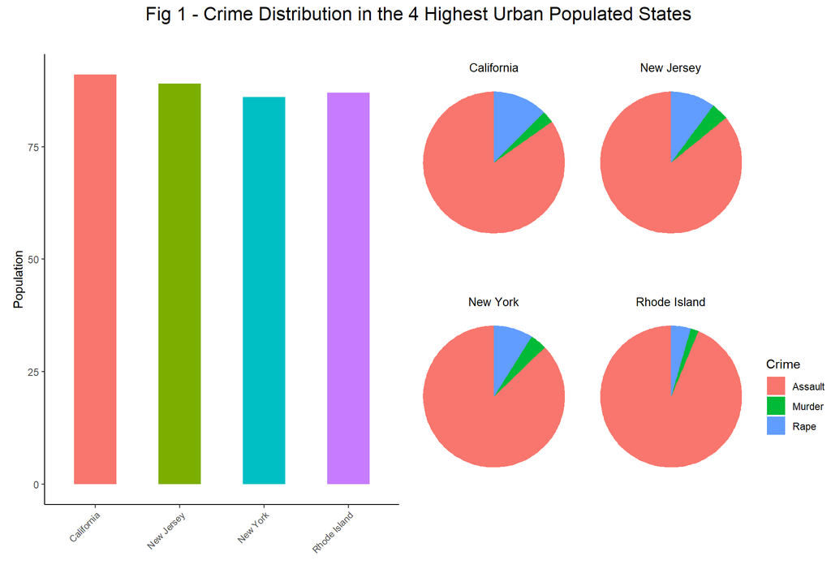

```r
p1 <- ggplot(data = dVT%>% filter(State == "California"),
       mapping = aes(x="", y = Value, fill= Crime)) +
        geom_bar(stat="identity", width=1) +
        coord_polar("y", start=0) +
        theme_void() +
        theme(legend.position = "none") +
        labs(title = "California") +
        theme(plot.title = element_text(size = 10, hjust = 0.5))

p2 <- ggplot(data = dVT%>% filter(State == "New Jersey"),
             mapping = aes(x="", y = Value, fill= Crime)) +
  geom_bar(stat="identity", width=1) +
  coord_polar("y", start=0) +
  theme_void() +
  theme(legend.position = "none") +
  labs(title = "New Jersey") +
  theme(plot.title = element_text(size = 10, hjust = 0.5))


p3 <- ggplot(data = dVT%>% filter(State == "New York"),
             mapping = aes(x="", y = Value, fill= Crime)) +
  geom_bar(stat="identity", width=1) +
  coord_polar("y", start=0) +
  theme_void() +
  theme(legend.position = "none") +
  labs(title = "New York") +
  theme(plot.title = element_text(size = 10, hjust = 0.5))

p4 <- ggplot(data = dVT%>% filter(State == "Rhode Island"),
             mapping = aes(x="", y = Value, fill= Crime)) +
  geom_bar(stat="identity", width=1) +
  coord_polar("y", start=0) +
  theme_void() +
  #theme(legend.position = "none") +
  labs(title = "Rhode Island") +
  theme(plot.title = element_text(size = 10, hjust = 0.5))


p5 <- ggplot(data = df1%>%
                   select(State, UrbanPop) %>%
                   arrange(desc(UrbanPop)) %>%
                   head(4),
       mapping = aes(x=State, y = UrbanPop, fill = State)) +
              geom_bar(stat="identity", width=0.5) +
              theme_classic() +
              theme(legend.position = "none") +
              labs(y = "Population", x = "") +
              theme(plot.title = element_text(size = 10, hjust = 0.5),
                    axis.text.x = element_text(angle = 45, hjust = 1, size = 8))

# Use patchwork to display multiple plots on a figure
fig1 <- (p5|(p1|p2)/(p3|p4)) +
        plot_annotation(title = "Fig 1 - Crime Distribution in the 4 Highest Urban Populated States",
                        #caption = "Fig 1: Crime distributions in the most urbanly-populated states",
                        theme = theme(plot.title = element_text(size = 16, hjust = 0.5))
                        )
                                     # plot.caption = element_text(hjust = 0, margin = margin(t = 10))))

print(fig1)
```

```r
ggsave("fig1.jpeg", fig1, width = 6, height = 4, dpi = 300)
```

**Question 2: What is the crime distributions in all states**

To visualize the crime distribution accross the US states all the crimes (murder, assault, rape) values were plotted as a scatterplot and it can be clearly seen from figure 2 that generally, the most arrest type is assaults arrests and the least is murder arrests.

*See below for the code chunk:*

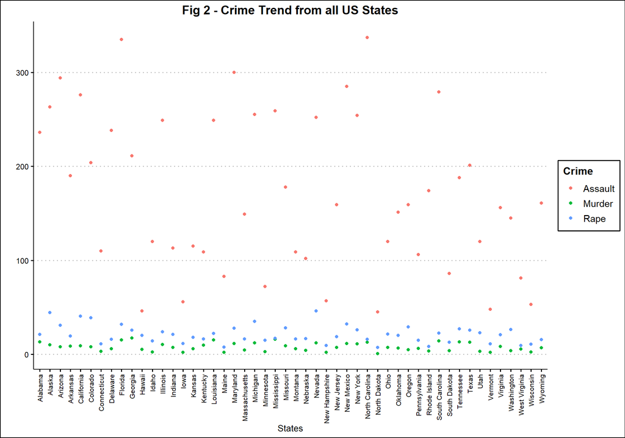

```r
fig2 <- ggplot(data = dVT, aes(x = State, y = Value, color = Crime)) +
  geom_point() +
  theme_clean() +
  labs(title = "Fig 2 - Crime Trend from all US States", x = "States", y = "") +
  theme(axis.text.x = element_text(angle = 90, vjust = 0.5, hjust = 1, size = 8),
        plot.title = element_text(hjust = 0.5))

print(fig2)
```

```r
ggsave("p2.jpeg",fig2, width = 6, height = 4, dpi = 300)
```

**Question 3: Which states have the most (least) murder arrests**

To visualize this the murder arrest was plotted using a bar chart with the states ranked from most murder arrests to least murder arrests. According to the data Georgia had the most muder arrest and North Dakota had the least (see fig 3).

*See below for the code chunk:*

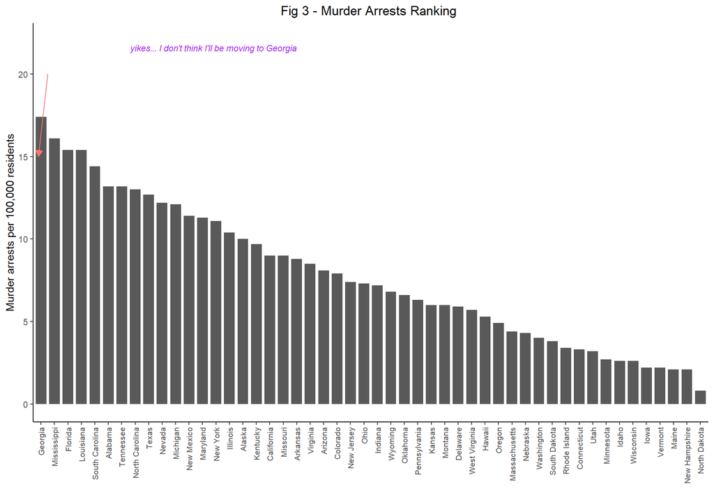

```r
fig3 <- ggplot(data = dVT %>% filter(Crime == "Murder"),
               mapping = aes(x = factor(State, levels = State[order(Value, decreasing = T)]), y = Value)) +
  geom_bar(stat="identity", width=0.8) +
  theme_classic() +
  labs(title = "Fig 3 - Murder Arrests Ranking ", x = "", y = "Murder arrests per 100,000 residents") +
  theme(axis.text.x = element_text(angle = 90, vjust = 0.5, hjust = 1, size = 8),
        plot.title = element_text(hjust = 0.5)) +
  geom_segment(aes(x = 1.5, y = 20, xend = 0.8, yend = 15, color = "red"),
                 arrow = arrow(type = "closed", length = unit(0.1, "inches"))) +
  annotate("text",
            x = 20, y = 22,
            label = "yikes... I don't think I'll be moving to Georgia",
            size = 3,
            color = "purple", fontface = "italic", hjust = 1, vjust = 1.5) +
  theme(legend.position = "none")

print(fig3)
```

```r
ggsave("fig3.jpeg",fig3, width = 6, height = 4, dpi = 300)
```